# Homework4

Data Visualization

Hanyu  
4/10/2022

### READ DATA & CLEAN DATA

```r
#Read data
data = read.csv(file = "business_data.csv")
summary(data)
```

```
    User_ID         Product_ID           Gender
 Min.   :1000001   Length:537577      Length:537577
 1st Qu.:1001495   Class :character   Class :character
 Median :1003031   Mode  :character   Mode  :character
 Mean   :1002992
 3rd Qu.:1004417
 Max.   :1006040

     Age              Occupation     City_Category
 Length:537577      Min.   : 0.000   Length:537577
 Class :character   1st Qu.: 2.000   Class :character
 Mode  :character   Median : 7.000   Mode  :character
                    Mean   : 8.083
                    3rd Qu.:14.000
                    Max.   :20.000

 Stay_In_Current_City_Years Marital_Status   Product_Category_1
 Length:537577              Min.   :0.0000   Min.   : 1.000
 Class :character           1st Qu.:0.0000   1st Qu.: 1.000
 Mode  :character           Median :0.0000   Median : 5.000
                            Mean   :0.4088   Mean   : 5.296
                            3rd Qu.:1.0000   3rd Qu.: 8.000
                            Max.   :1.0000   Max.   :18.000

 Product_Category_2 Product_Category_3    Purchase
 Min.   : 2.00      Min.   : 3.0       Min.   :  185
 1st Qu.: 5.00      1st Qu.: 9.0       1st Qu.: 5866
 Median : 9.00      Median :14.0       Median : 8062
 Mean   : 9.84      Mean   :12.7       Mean   : 9334
 3rd Qu.:15.00      3rd Qu.:16.0       3rd Qu.:12073
 Max.   :18.00      Max.   :18.0       Max.   :23961
 NA's   :166986     NA's   :373299
```

```r
#Clean data
data = data[,-11]       #Drop this column because Product_Category_3 has too many missing values
data[is.na(data)] <- 0  #Fill in the missing values of Product_Category_2 with 0
data = data[,-1]
head(data)
```

```
  Product_ID Gender   Age Occupation City_Category
1  P00069042      F  0-17         10             A
2  P00248942      F  0-17         10             A
3  P00087842      F  0-17         10             A
4  P00085442      F  0-17         10             A
5  P00285442      M   55+         16             C
6  P00193542      M 26-35         15             A
  Stay_In_Current_City_Years Marital_Status Product_Category_1
1                          2              0                  3
2                          2              0                  1
3                          2              0                 12
4                          2              0                 12
5                         4+              0                  8
6                          3              0                  1
  Product_Category_2 Purchase
1                  0     8370
2                  6    15200
3                  0     1422
4                 14     1057
5                  0     7969
6                  2    15227
```

### Statistics for age

```r
age_group <- group_by(data, Age) %>%
  summarise(n = n(),
            Mea_Pur = mean(Purchase),
            Med_Pur = median(Purchase),
            Sd_Pur  = sd(Purchase),
            na.rm = TRUE) %>%
  mutate(freq = n / sum(n))
age_group
```

```
# A tibble: 7 × 7
  Age        n Mea_Pur Med_Pur Sd_Pur na.rm   freq
  <chr>  <int>   <dbl>   <dbl>  <dbl> <lgl>  <dbl>
1 0-17   14707   9020.    8009  5060. TRUE  0.0274
2 18-25  97634   9235.    8041  4996. TRUE  0.182
3 26-35 214690   9315.    8043  4974. TRUE  0.399
4 36-45 107499   9401.    8076  4978. TRUE  0.200
5 46-50  44526   9285.    8050  4921. TRUE  0.0828
6 51-55  37618   9621.    8172  5035. TRUE  0.0700
7 55+    20903   9454.    8127  4939. TRUE  0.0389
```

### Statistics for city category

```r
city_group <- group_by(data, City_Category) %>%
  summarise(n = n(),
            Mea_Pur = mean(Purchase),
            Med_Pur = median(Purchase),
            Sd_Pur  = sd(Purchase),
            na.rm = TRUE) %>%
  mutate(freq = n / sum(n))
city_group
```

```
# A tibble: 3 × 7
  City_Category      n Mea_Pur Med_Pur Sd_Pur na.rm  freq
  <chr>          <int>   <dbl>   <dbl>  <dbl> <lgl> <dbl>
1 A             144638   8958.    7941  4867. TRUE  0.269
2 B             226493   9199.    8015  4927. TRUE  0.421
3 C             166446   9844.    8618  5109. TRUE  0.310
```

### Visualization for univariate

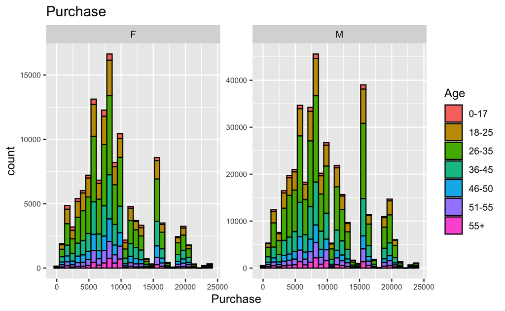

```r
#Purchase Amount Distribution
ggplot(data, aes(Purchase, fill =Age)) +
  geom_histogram(color="black")+
  labs(title = "Purchase") +
  theme(axis.text=element_text(size=7)) +
  facet_wrap(vars(Gender), scales = "free")
```

### Visualization for bivariate

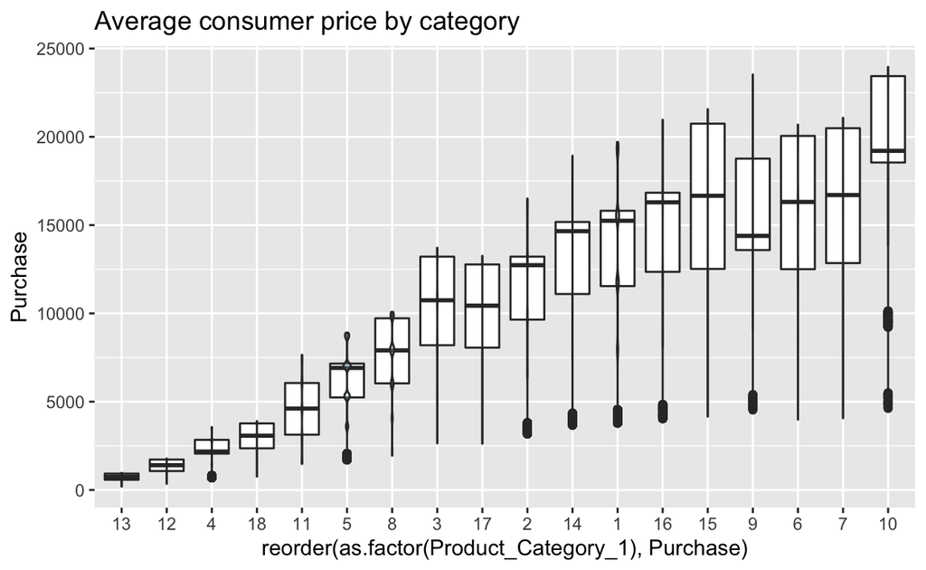

```r
#Average consumer price by category
  ggplot(data,aes(x=reorder(as.factor(Product_Category_1),Purchase),y=Purchase))+
  geom_boxplot()+
  geom_violin(scale="count",fill="lightblue",alpha=.3)+
  labs(title = "Average consumer price by category")
```

### Visualization explain

I visualize the product category with the purchase amount. The image shows that the most preferred product category number by consumers is #1, which is significantly higher than the other products; followed by #2, #5, and #8, which are generally more average; while #10, #11, #12, and #13 products are almost unpopular with consumers. In the average consumption of each category, the price of category 10 is the highest, and the distribution is significantly asymmetric.

### Limitations of visualization

In the first visualization, both males and females have anomalously high values at 15000, but anomalously low values around 15000 for unknown reasons. Also, the relationship between marital status and spending amount is not reflected in the graph. For the box-line graphs, it is true that some necessary illustrations may lead to difficulties in understanding.

In subsequent work, I may include more illustrations and more visual graphs to better show the relationship between the data.